# PLS2 — Relación bacterias-metabolitos — Leonard et al. (2021)

### 5.3.2 Gráficos exploratorios para grupo Control

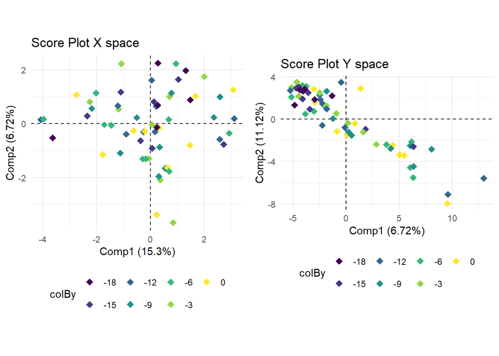

```r
covar_time_control <- factor(species_control$relative_month,
                              levels = c(-18, -15, -12, -9, -6, -3, 0))

p1_control <- plsPlot(modelo_control, type = "scoresX", comp = 1:2,
                       colBy = data.frame(relative_month = covar_time_control),
                       labels = FALSE, ellipses = FALSE) +
  scale_color_viridis_d(option = "viridis") +
  guides(fill = "none", shape = "none")
p2_control <- plsPlot(modelo_control, type = "scoresY", comp = 1:2,
                       colBy = data.frame(relative_month = covar_time_control),
                       labels = FALSE, ellipses = FALSE) +
  scale_color_viridis_d(option = "viridis") +
  guides(fill = "none", shape = "none")
grid.arrange(p1_control, p2_control, ncol = 2)
```

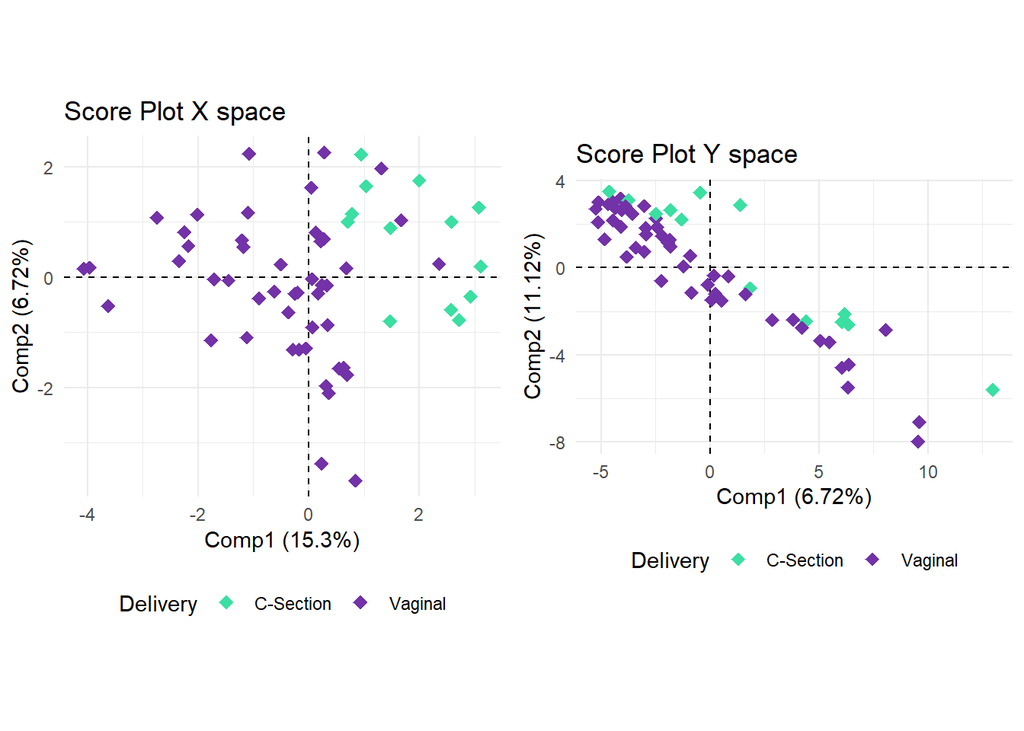

```r
covar_deliv <- data.frame(Delivery = species_control$Delivery_Mode)
p1_control_deliv <- plsPlot(modelo_control, type = "scoresX", comp = 1:2,
                    colBy = covar_deliv,labels = FALSE, ellipses = FALSE)

p2_control_deliv <- plsPlot(modelo_control, type = "scoresY", comp = 1:2,
                    colBy = covar_deliv,
                    labels = FALSE, ellipses = FALSE)
grid.arrange(p1_control_deliv, p2_control_deliv, ncol = 2)
```

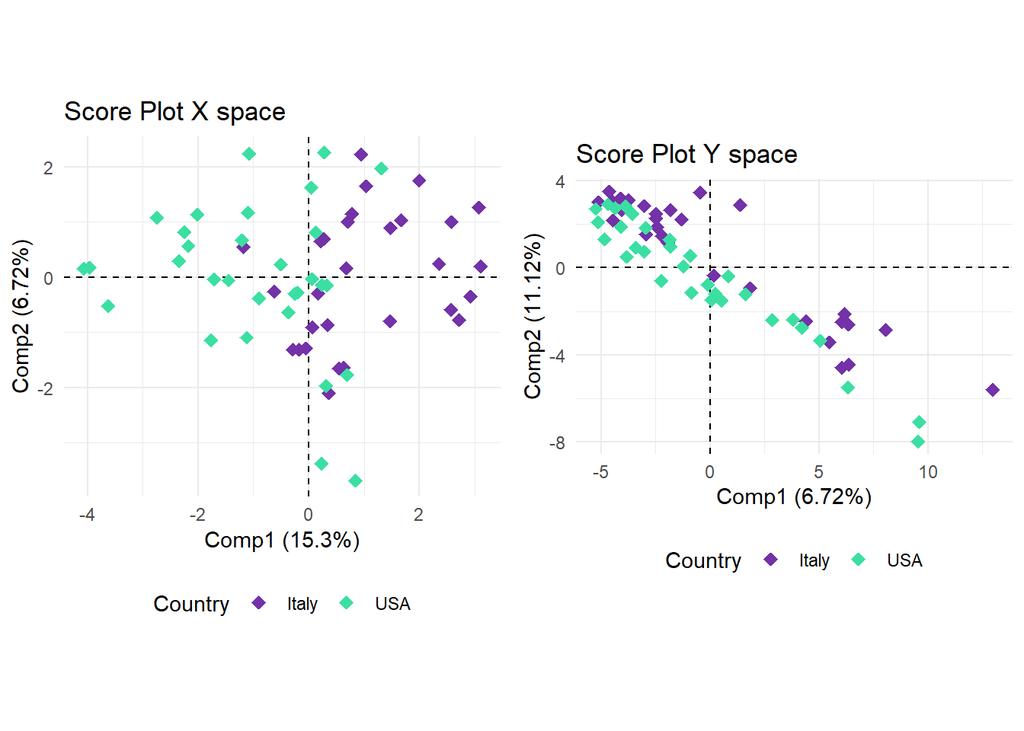

```r
covar_country <- data.frame(Country = species_control$Country)
p1_control_country <- plsPlot(modelo_control, type = "scoresX", comp = 1:2,
                    colBy = covar_country,labels = FALSE, ellipses = FALSE)

p2_control_country <- plsPlot(modelo_control, type = "scoresY", comp = 1:2,
                    colBy = covar_country,
                    labels = FALSE, ellipses = FALSE)
grid.arrange(p1_control_country, p2_control_country, ncol = 2)
```

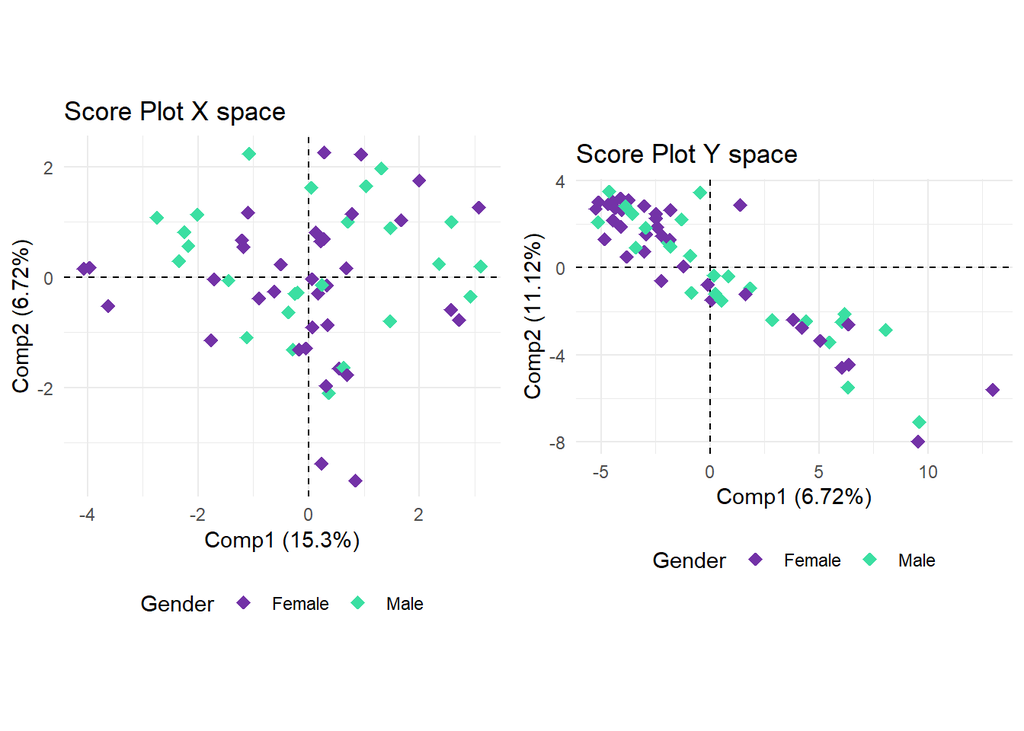

```r
covar_gender <- data.frame(Gender = species_control$Gender)
p1_control_gender <- plsPlot(modelo_control, type = "scoresX", comp = 1:2,
                    colBy = covar_gender,labels = FALSE, ellipses = FALSE)

p2_control_gender <- plsPlot(modelo_control, type = "scoresY", comp = 1:2,
                    colBy = covar_gender,
                    labels = FALSE, ellipses = FALSE)
grid.arrange(p1_control_gender, p2_control_gender, ncol = 2)
```

## 5.4 Loadings

### 5.4.1 Loadings case

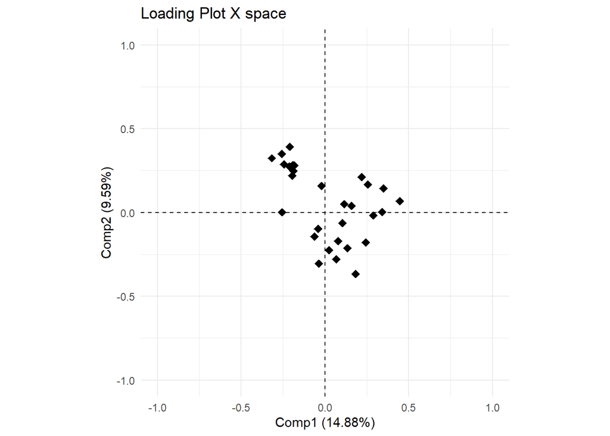

```r
plsPlot(modelo_case, type = "loadingsX", comp = 1:2,
                         shape = "point", labels = FALSE, repel = TRUE)
```

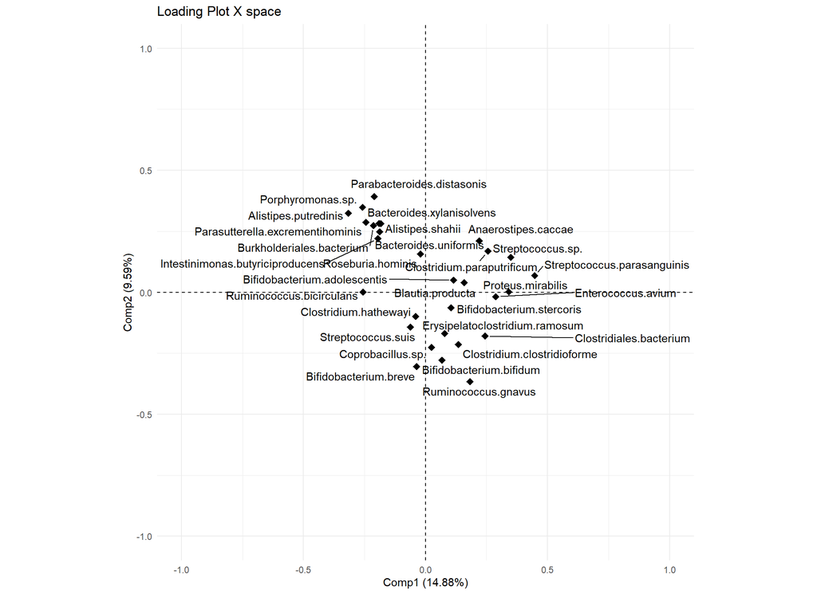

```r
plsPlot(modelo_case, type = "loadingsX", comp = 1:2,
        shape = "point", labels = TRUE, repel = TRUE)
```

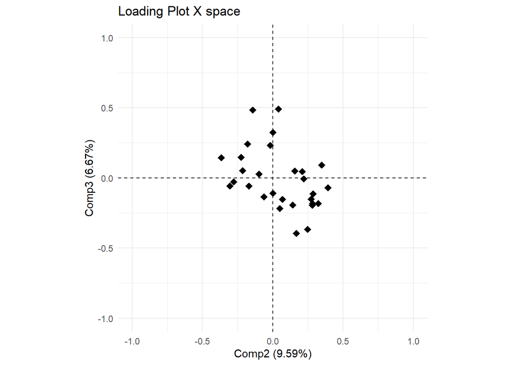

```r
plsPlot(modelo_case, type = "loadingsX", comp = 2:3,
                         shape = "point", labels = FALSE, repel = TRUE)
```

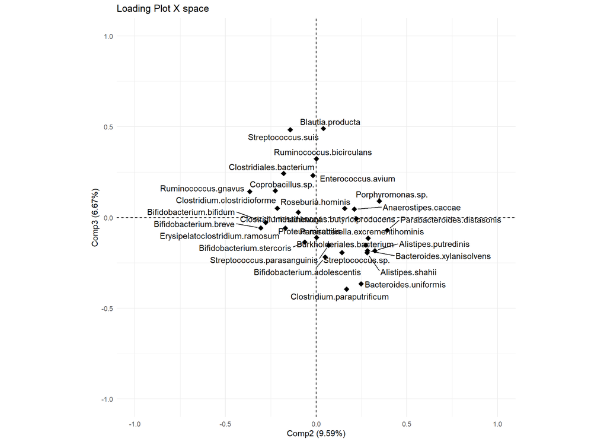

```r
plsPlot(modelo_case, type = "loadingsX", comp = 2:3,
        shape = "point", labels = TRUE, repel = TRUE)
```

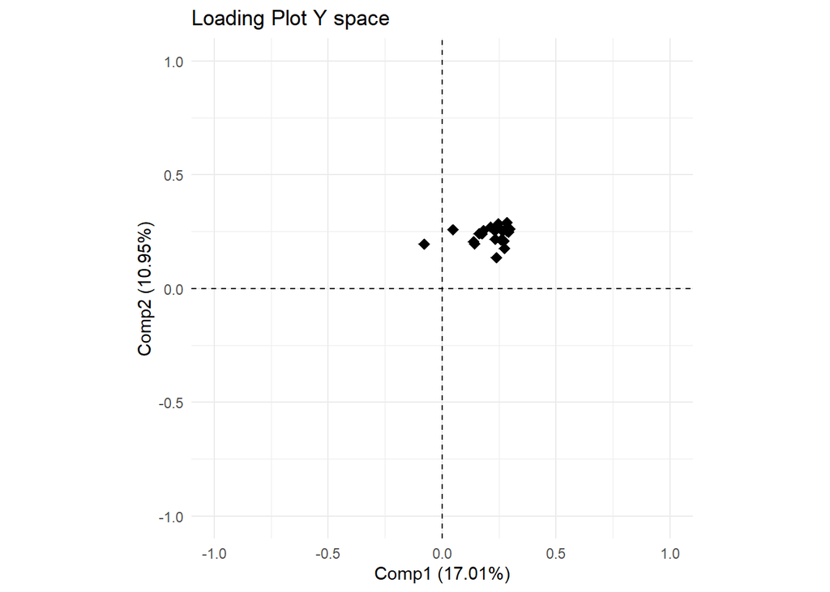

```r
plsPlot(modelo_case, type = "loadingsY", comp = 1:2,
                         shape = "point", labels = FALSE, repel = TRUE)
```

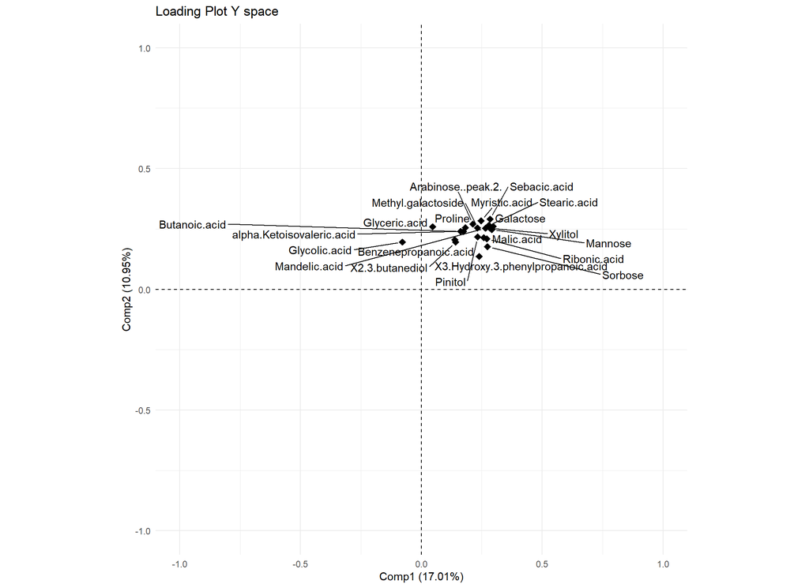

```r
plsPlot(modelo_case, type = "loadingsY", comp = 1:2,
        shape = "point", labels = TRUE, repel = TRUE)
```

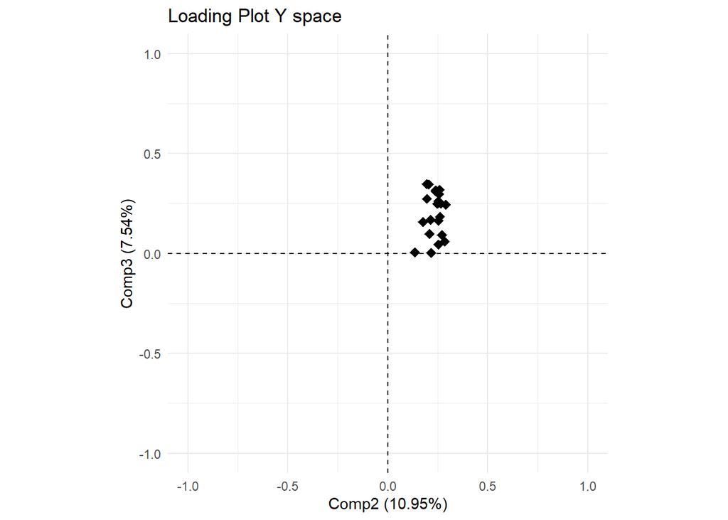

```r
plsPlot(modelo_case, type = "loadingsY", comp = 2:3,
                         shape = "point", labels = FALSE, repel = TRUE)
```

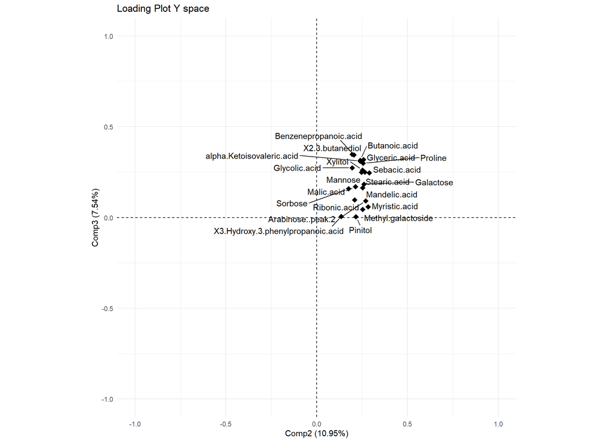

```r
plsPlot(modelo_case, type = "loadingsY", comp = 2:3,
        shape = "point", labels = TRUE, repel = TRUE)
```

### 5.4.2 Loadings control

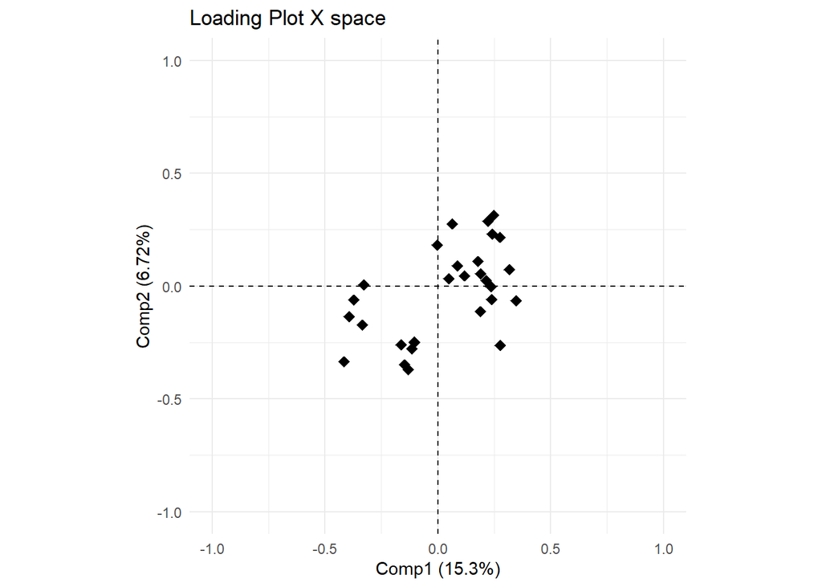

```r
plsPlot(modelo_control, type = "loadingsX", comp = 1:2,
                            shape = "point", labels = FALSE, repel = TRUE)
```

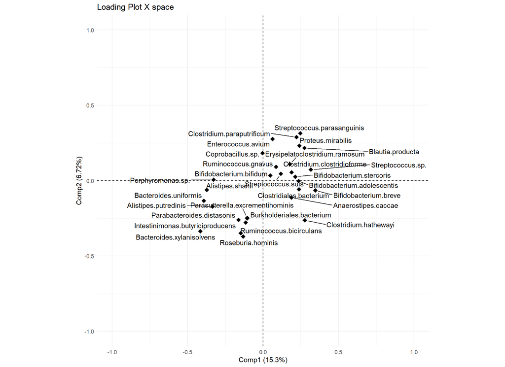

```r
plsPlot(modelo_control, type = "loadingsX", comp = 1:2,
        shape = "point", labels = TRUE, repel = TRUE)
```

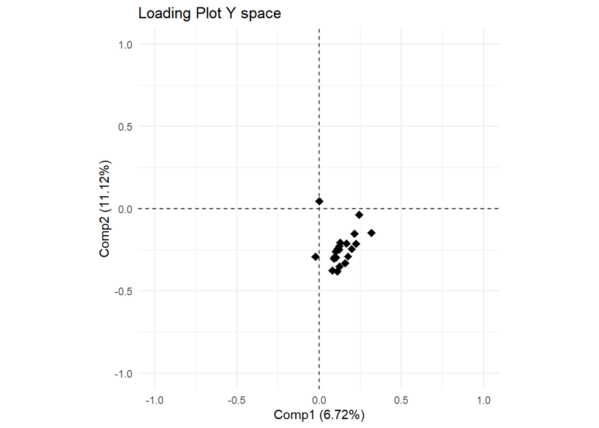

```r
plsPlot(modelo_control, type = "loadingsY", comp = 1:2,
                            shape = "point", labels = FALSE, repel = TRUE)
```

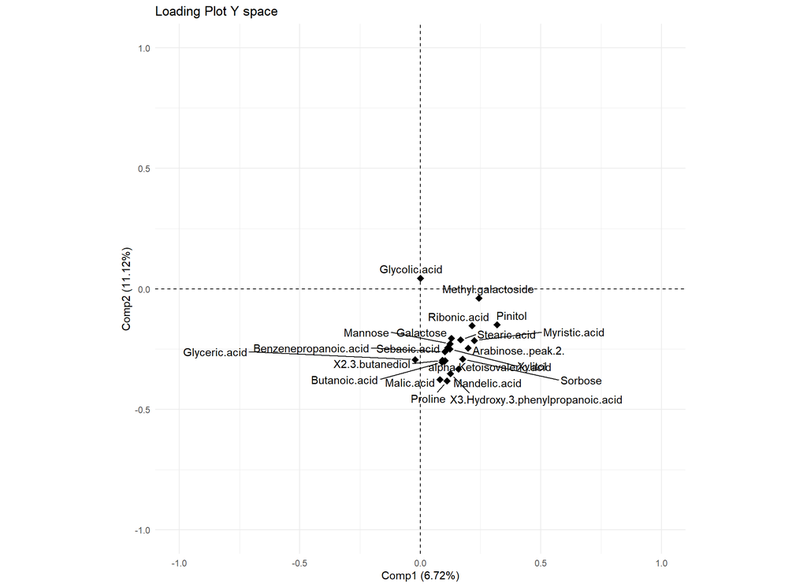

```r
plsPlot(modelo_control, type = "loadingsY", comp = 1:2,
        shape = "point", labels = TRUE, repel = TRUE)
```

## 5.5 Weights

### 5.5.1 Weights case

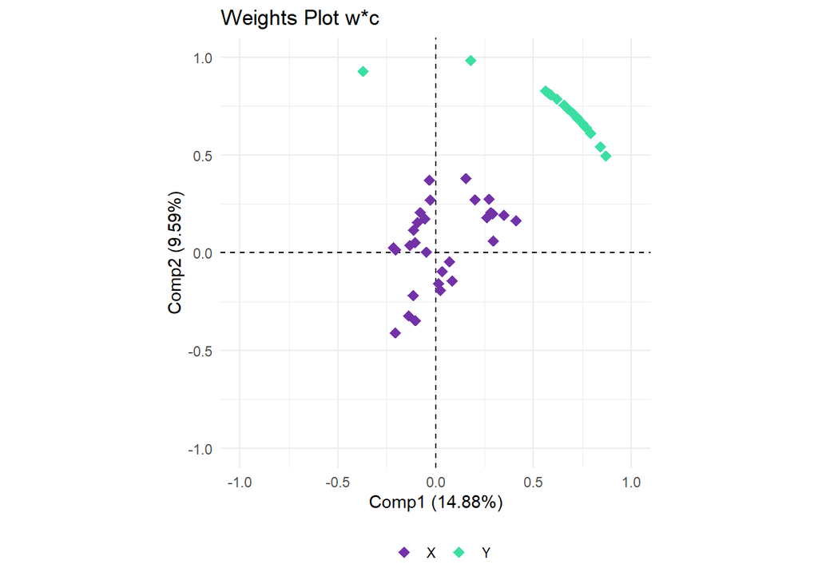

```r
plsPlot(modelo_case, type = "weights", comp = 1:2, shape = "point",
        labels = FALSE, repel = TRUE)
```

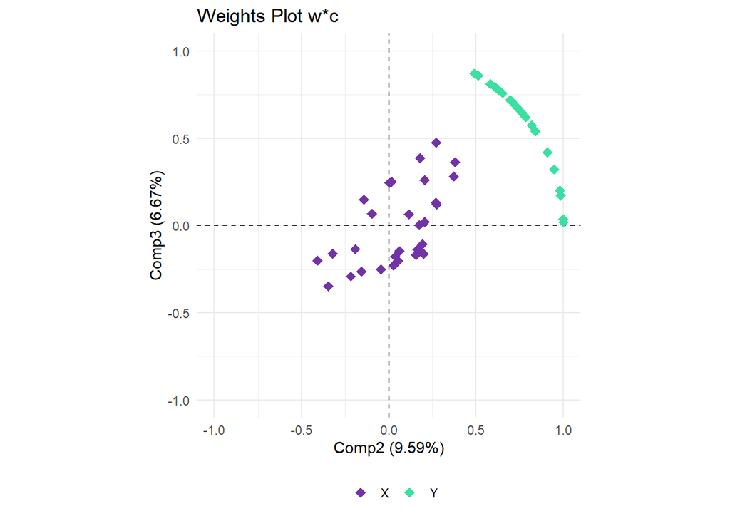

```r
plsPlot(modelo_case, type = "weights", comp = 2:3, shape = "point",
        labels = FALSE, repel = TRUE)
```

Versión con etiquetas:

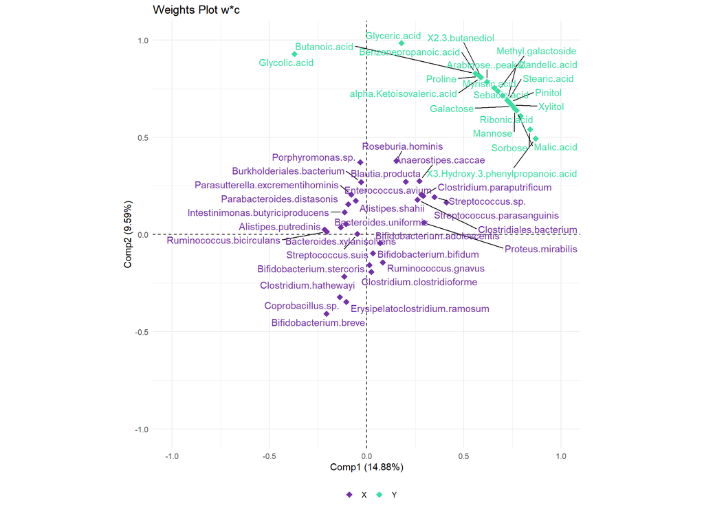

```r
plsPlot(modelo_case, type = "weights", comp = 1:2,
        labels = TRUE, repel = TRUE, shape='point')
```

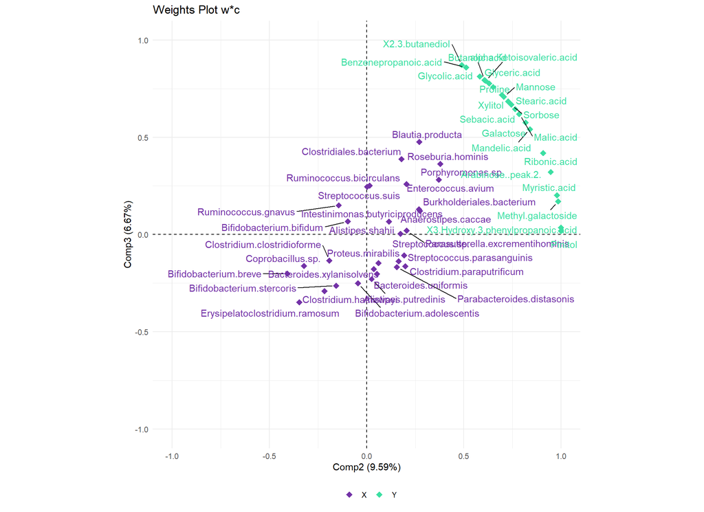

```r
plsPlot(modelo_case, type = "weights", comp = 2:3,
        labels = TRUE, repel = TRUE, shape='point')
```

### 5.5.2 Weights control

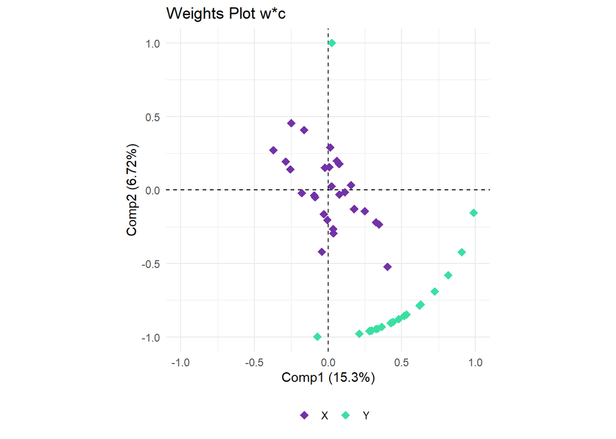

```r
plsPlot(modelo_control, type = "weights", comp = 1:2, shape = "point",
        labels = FALSE, repel = TRUE)
```

Versión con etiquetas:

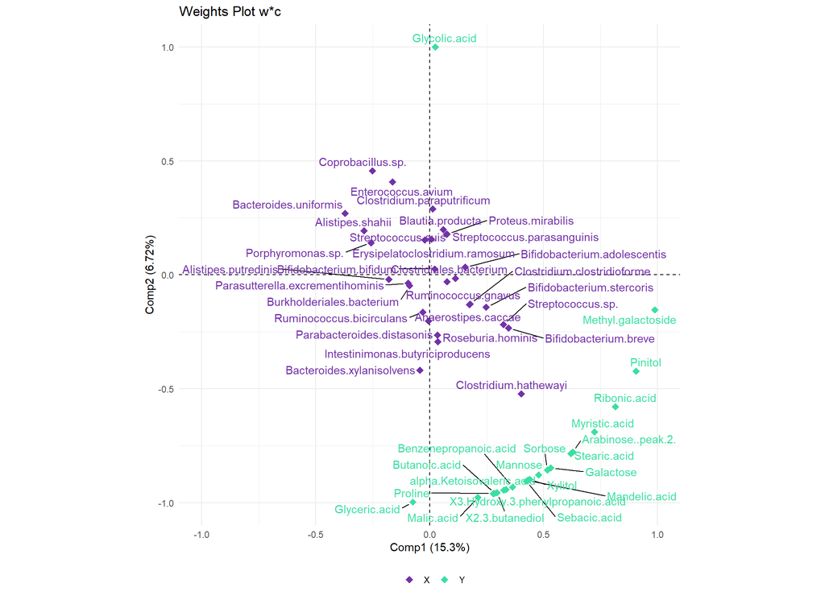

```r
plsPlot(modelo_control, type = "weights", comp = 1:2,
        labels = TRUE, repel = TRUE, shape='point')
```

## 5.6 Significación de relaciones bacteria-metabolito, por grupo

```r
# Jackknife: análisis complementario
set.seed(123)
jack_case <- plsVarSel(
  modelo_case,
  type = "Jack",
  rep = 100,
  threshold = 0.05
)
```

```r
set.seed(123)
jack_control <- plsVarSel(
  modelo_control,
  type = "Jack",
  rep = 100,
  threshold = 0.05
)
```

```r
# Permutación: criterio principal de selección de relaciones.
# Se utilizan 1000 repeticiones para obtener una estimación más estable.
set.seed(123)
perm_case <- plsVarSel(
  modelo_case,
  type = "Perm",
  rep = 1000,
  threshold = 0.05
)
```

```r
set.seed(123)
perm_control <- plsVarSel(
  modelo_control,
  type = "Perm",
  rep = 1000,
  threshold = 0.05
)
```

```r
# VIP: evidencia complementaria a nivel de bacteria, no criterio obligatorio
vip_case <- plsVarSel(modelo_case, type = "VIP")
```

```r
vip_control <- plsVarSel(modelo_control, type = "VIP")
```

```r
cat(
  "Case    - Jack:", sum(sapply(jack_case, nrow) > 0),
  " Perm:", sum(sapply(perm_case, nrow) > 0),
  " VIP:", nrow(vip_case), "\n"
)
```

```
## Case    - Jack: 0  Perm: 12  VIP: 13
```

```r
cat(
  "Control - Jack:", sum(sapply(jack_control, nrow) > 0),
  " Perm:", sum(sapply(perm_control, nrow) > 0),
  " VIP:", nrow(vip_control), "\n"
)
```

```
## Control - Jack: 0  Perm: 14  VIP: 13
```

Igual que en el modelo conjunto, el jackknife no encuentra relaciones significativas en ninguno de los dos grupos.

```r
tabla_case <- perm_case[sapply(perm_case, nrow) > 0] %>%
  imap_dfr(~ tibble(
    metabolito = .y,
    bacteria   = rownames(.x),
    p_perm     = .x$pValPerm
  )) %>%
  mutate(en_VIP = bacteria %in% rownames(vip_case)) %>%
  mutate(coeficiente = modelo_case$coefficients[cbind(bacteria, metabolito)]) %>%
  arrange(metabolito, p_perm)

tabla_control <- perm_control[sapply(perm_control, nrow) > 0] %>%
  imap_dfr(~ tibble(
    metabolito = .y,
    bacteria   = rownames(.x),
    p_perm     = .x$pValPerm
  )) %>%
  mutate(en_VIP = bacteria %in% rownames(vip_control)) %>%
  mutate(coeficiente = modelo_control$coefficients[cbind(bacteria, metabolito)]) %>%
  arrange(metabolito, p_perm)

tabla_case
```

```
## # A tibble: 34 × 5
##    metabolito            bacteria                      p_perm en_VIP coeficiente
##    <chr>                 <chr>                          <dbl> <lgl>        <dbl>
##  1 Benzenepropanoic.acid Roseburia.hominis              0.038 TRUE         0.224
##  2 Benzenepropanoic.acid Blautia.producta               0.04  TRUE         0.248
##  3 Butanoic.acid         Roseburia.hominis              0.035 TRUE         0.230
##  4 Butanoic.acid         Blautia.producta               0.042 TRUE         0.248
##  5 Galactose             Coprobacillus.sp.              0.04  FALSE       -0.155
##  6 Glyceric.acid         Roseburia.hominis              0.023 TRUE         0.221
##  7 Glyceric.acid         Porphyromonas.sp.              0.032 TRUE         0.184
##  8 Glyceric.acid         Blautia.producta               0.038 TRUE         0.231
##  9 Glyceric.acid         Erysipelatoclostridium.ramos…  0.045 FALSE       -0.205
## 10 Glycolic.acid         Porphyromonas.sp.              0.004 TRUE         0.152
## # ℹ 24 more rows
```

```r
tabla_control
```

```
## # A tibble: 38 × 5
##    metabolito         bacteria                  p_perm en_VIP coeficiente
##    <chr>              <chr>                      <dbl> <lgl>        <dbl>
##  1 Arabinose..peak.2. Clostridium.hathewayi      0.02  TRUE         0.208
##  2 Arabinose..peak.2. Coprobacillus.sp.          0.029 TRUE        -0.162
##  3 Butanoic.acid      Clostridium.hathewayi      0.04  TRUE         0.195
##  4 Butanoic.acid      Coprobacillus.sp.          0.049 TRUE        -0.162
##  5 Glyceric.acid      Bacteroides.xylanisolvens  0.049 TRUE         0.124
##  6 Malic.acid         Clostridium.hathewayi      0.003 TRUE         0.230
##  7 Malic.acid         Bacteroides.xylanisolvens  0.008 TRUE         0.154
##  8 Malic.acid         Coprobacillus.sp.          0.01  TRUE        -0.192
##  9 Malic.acid         Enterococcus.avium         0.03  TRUE        -0.167
## 10 Mandelic.acid      Clostridium.hathewayi      0.008 TRUE         0.237
## # ℹ 28 more rows
```

```r
write_csv(tabla_case,    file.path(processed_dir, "relaciones_bacteria_metabolito_case.csv"))
write_csv(tabla_control, file.path(processed_dir, "relaciones_bacteria_metabolito_control.csv"))
```

## 5.7 Comparación Case vs. Control

```r
pares_case    <- paste(tabla_case$bacteria, tabla_case$metabolito, sep = "__")
pares_control <- paste(tabla_control$bacteria, tabla_control$metabolito, sep = "__")

cat("Relaciones solo en Case:   ", length(setdiff(pares_case, pares_control)), "\n")
```

```
## Relaciones solo en Case:    33
```

```r
cat("Relaciones solo en Control:", length(setdiff(pares_control, pares_case)), "\n")
```

```
## Relaciones solo en Control: 37
```

```r
cat("Relaciones en ambos:       ", length(intersect(pares_case, pares_control)), "\n")
```

```
## Relaciones en ambos:        1
```

```r
cat("\nBacterias en Case:   ", paste(sort(unique(tabla_case$bacteria)), collapse = ", "), "\n")
```

```
##
## Bacterias en Case:    Bifidobacterium.breve, Bifidobacterium.stercoris, Blautia.producta, Burkholderiales.bacterium, Clostridiales.bacterium, Clostridium.hathewayi, Coprobacillus.sp., Erysipelatoclostridium.ramosum, Porphyromonas.sp., Roseburia.hominis
```

```r
cat("Bacterias en Control:", paste(sort(unique(tabla_control$bacteria)), collapse = ", "), "\n")
```

```
## Bacterias en Control: Alistipes.shahii, Bacteroides.uniformis, Bacteroides.xylanisolvens, Bifidobacterium.breve, Clostridium.hathewayi, Coprobacillus.sp., Enterococcus.avium, Streptococcus.sp.
```

```r
intersect(pares_case, pares_control)
```

```
## [1] "Coprobacillus.sp.__Myristic.acid"
```

### 5.7.1 Solapamiento con VIP dentro de cada grupo

Se comprueba, para cada grupo por separado, qué proporción de las relaciones seleccionadas mediante permutación cuentan además con respaldo del VIP. El criterio principal para definir una relación candidata es la permutación ($p<0.05$); el VIP se utiliza únicamente como evidencia complementaria a nivel de bacteria.

```r
resumen_vip <- bind_rows(
  tibble(
    grupo = "Case",
    relaciones = nrow(tabla_case),
    con_VIP = sum(tabla_case$en_VIP),
    porcentaje_VIP = 100 * mean(tabla_case$en_VIP)
  ),
  tibble(
    grupo = "Control",
    relaciones = nrow(tabla_control),
    con_VIP = sum(tabla_control$en_VIP),
    porcentaje_VIP = 100 * mean(tabla_control$en_VIP)
  )
)

resumen_vip
```

```
## # A tibble: 2 × 4
##   grupo   relaciones con_VIP porcentaje_VIP
##   <chr>        <int>   <int>          <dbl>
## 1 Case            34      23           67.6
## 2 Control         38      37           97.4
```

También se examinan de forma específica las relaciones seleccionadas por permutación cuya bacteria no presenta VIP > 1:

```r
tabla_case %>% filter(!en_VIP)
```

```
## # A tibble: 11 × 5
##    metabolito    bacteria                       p_perm en_VIP coeficiente
##    <chr>         <chr>                           <dbl> <lgl>        <dbl>
##  1 Galactose     Coprobacillus.sp.               0.04  FALSE      -0.155
##  2 Glyceric.acid Erysipelatoclostridium.ramosum  0.045 FALSE      -0.205
##  3 Glycolic.acid Erysipelatoclostridium.ramosum  0.01  FALSE      -0.155
##  4 Glycolic.acid Clostridium.hathewayi           0.018 FALSE      -0.113
##  5 Glycolic.acid Coprobacillus.sp.               0.033 FALSE      -0.0965
##  6 Glycolic.acid Bifidobacterium.stercoris       0.036 FALSE      -0.104
##  7 Glycolic.acid Burkholderiales.bacterium       0.046 FALSE       0.0906
##  8 Myristic.acid Coprobacillus.sp.               0.049 FALSE      -0.135
##  9 Sebacic.acid  Coprobacillus.sp.               0.046 FALSE      -0.172
## 10 Stearic.acid  Coprobacillus.sp.               0.047 FALSE      -0.165
## 11 Xylitol       Coprobacillus.sp.               0.045 FALSE      -0.163
```

```r
tabla_control %>% filter(!en_VIP)
```

```
## # A tibble: 1 × 5
##   metabolito bacteria         p_perm en_VIP coeficiente
##   <chr>      <chr>             <dbl> <lgl>        <dbl>
## 1 Pinitol    Alistipes.shahii  0.033 FALSE       -0.121
```

# 6. Representación de las relaciones mediante grafos

Se representan las relaciones bacteria-metabolito seleccionadas mediante permutación como grafos bipartitos: un nodo por bacteria, un nodo por metabolito, y una arista por cada relación significativa de la tabla correspondiente. Se usa `ggraph`/`tidygraph` (sobre `igraph`) en vez de `igraph` base, porque permite reposicionar automáticamente las etiquetas para evitar solapes (`ggrepel`), igual que ya se hace en los gráficos de loadings/weights del PLS — con `igraph` base, forzar manualmente ángulo y distancia de cada etiqueta no bastaba para evitar que varias se solaparan cuando hay muchos nodos en una misma fila.

```r
plot_bipartite_graph <- function(tabla, title, seed = 123) {
  edges <- tabla %>% select(bacteria, metabolito)

  g <- as_tbl_graph(graph_from_data_frame(edges, directed = FALSE)) %>%
    activate(nodes) %>%
    mutate(
      type = name %in% unique(tabla$bacteria),
      tipo = if_else(type, "Bacteria", "Metabolito")
    )

  set.seed(seed)
  ggraph(g, layout = "bipartite") +
    geom_edge_link(color = "grey70", alpha = 0.6) +
    geom_node_point(aes(color = tipo, shape = tipo), size = 5) +
    geom_node_text(aes(label = name), repel = TRUE, size = 3.3,
                    max.overlaps = Inf, seed = seed) +
    scale_color_manual(values = c("Bacteria" = "#3182bd", "Metabolito" = "#31a354")) +
    labs(title = title, color = NULL, shape = NULL) +
    theme_void() +
    theme(legend.position = "bottom", plot.title = element_text(hjust = 0.5))
}
```

Alternativa para cuando el grafo conjunto tiene demasiadas relaciones para leerse bien: dividir la tabla en bloques (por ejemplo, de 20 relaciones) y graficar cada bloque por separado.

```r
plot_bipartite_graph_split <- function(tabla, title, block_size = 20, seed = 123) {
  n_blocks <- ceiling(nrow(tabla) / block_size)
  bloques <- split(tabla, ceiling(seq_len(nrow(tabla)) / block_size))

  imap(bloques, function(sub_tabla, i) {
    plot_bipartite_graph(sub_tabla, paste0(title, " (bloque ", i, "/", n_blocks, ")"), seed = seed)
  })
}
```

## 6.1 Grafo — modelo conjunto

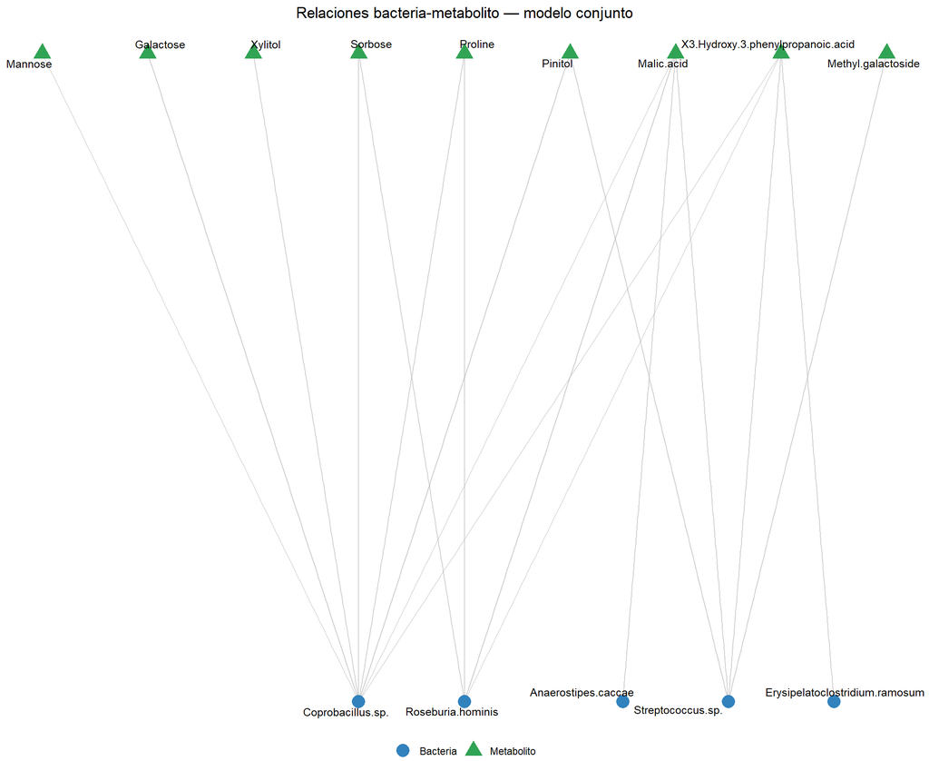

```r
plot_bipartite_graph(tabla_relaciones, "Relaciones bacteria-metabolito — modelo conjunto")
```

### 6.1.0 Alternativa: división en bloques

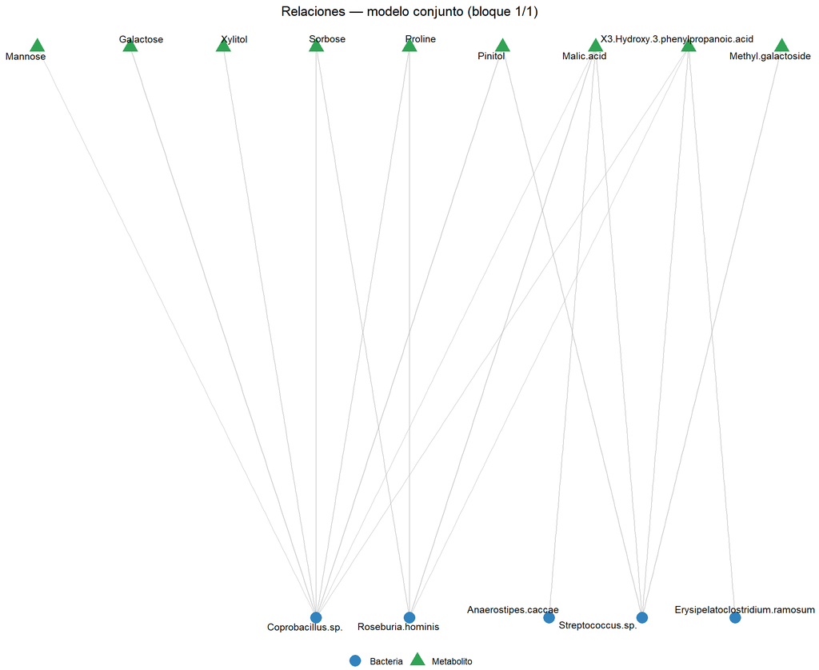

```r
walk(plot_bipartite_graph_split(tabla_relaciones, "Relaciones — modelo conjunto", block_size = 20), print)
```

### 6.1.1 Alternativa: un subgrafo por bacteria

```r
plot_star_by_bacteria <- function(tabla) {
  bacterias <- sort(unique(tabla$bacteria))

  plots <- map(bacterias, function(b) {
    sub_tabla <- tabla %>% filter(bacteria == b)
    edges <- sub_tabla %>% select(bacteria, metabolito)

    g <- as_tbl_graph(graph_from_data_frame(edges, directed = FALSE)) %>%
      activate(nodes) %>%
      mutate(
        type = name == b,
        tipo = if_else(type, "Bacteria", "Metabolito")
      )

    ggraph(g, layout = "star") +
      geom_edge_link(color = "grey70", alpha = 0.6) +
      geom_node_point(aes(color = tipo, shape = tipo), size = 5) +
      geom_node_text(aes(label = name), repel = TRUE, size = 4, max.overlaps = Inf) +
      scale_color_manual(values = c("Bacteria" = "#3182bd", "Metabolito" = "#31a354")) +
      labs(title = b) +
      theme_void() +
      theme(legend.position = "none", plot.title = element_text(size = 13, hjust = 0.5))
  })

  set_names(plots, bacterias)
}
```

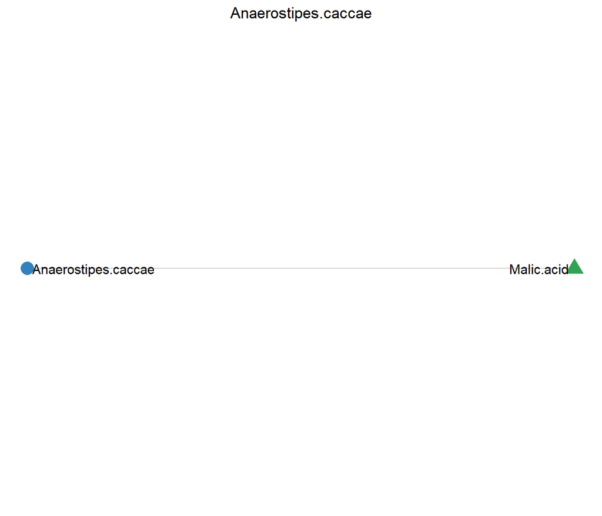

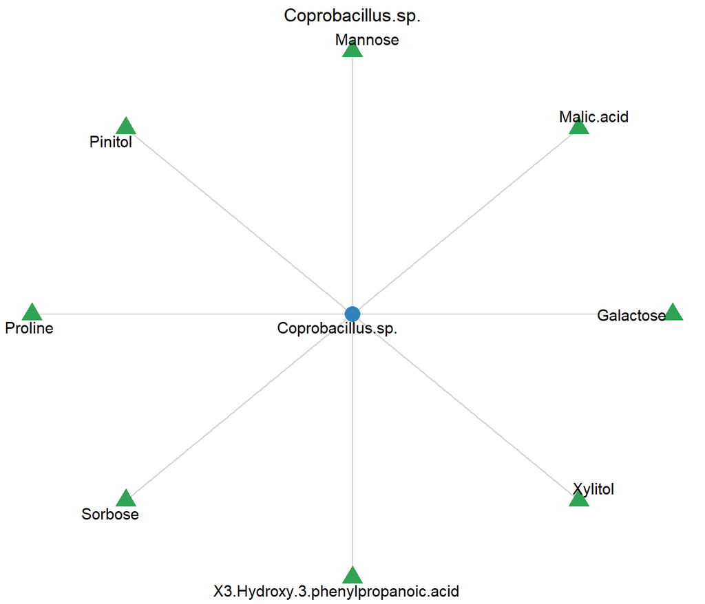

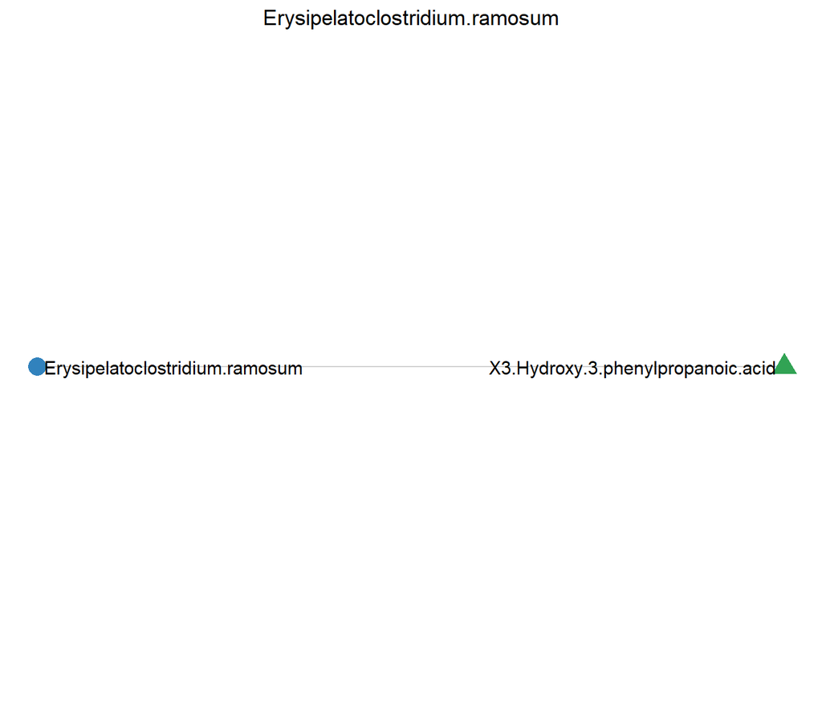

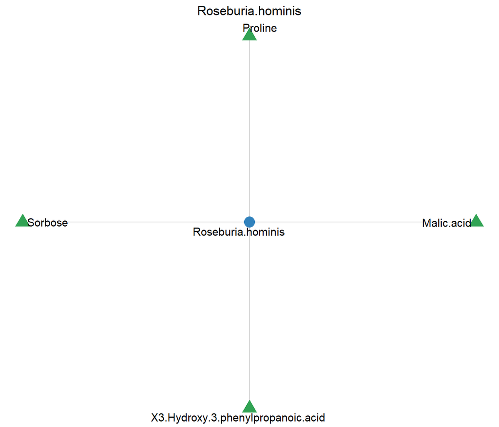

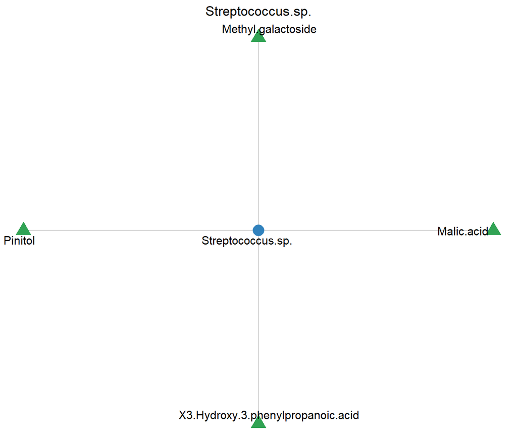

```r
walk(plot_star_by_bacteria(tabla_relaciones), print)
```

## 6.2 Grafo — Case

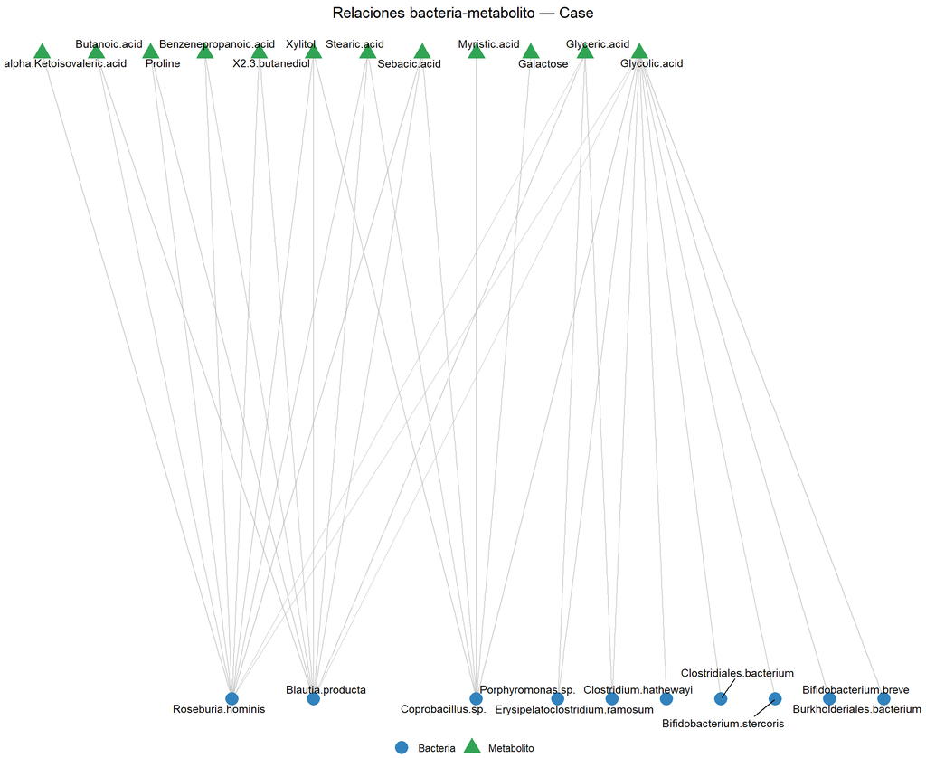

```r
plot_bipartite_graph(tabla_case, "Relaciones bacteria-metabolito — Case")
```

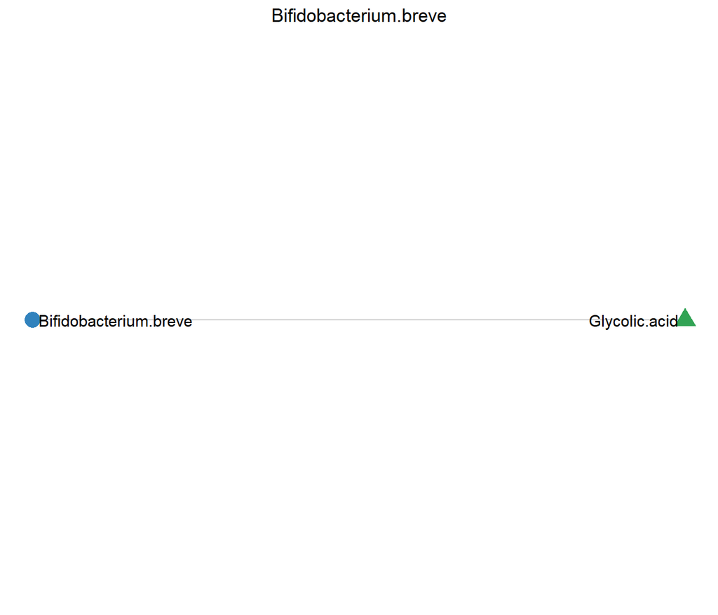

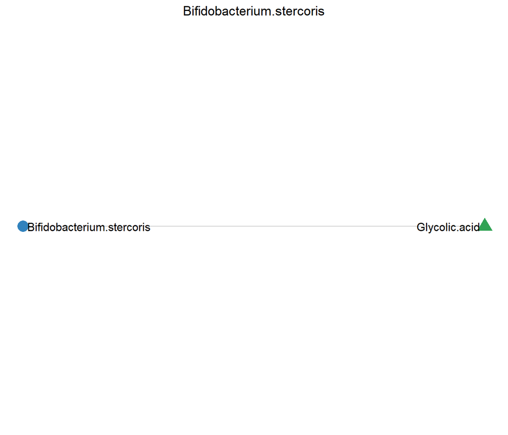

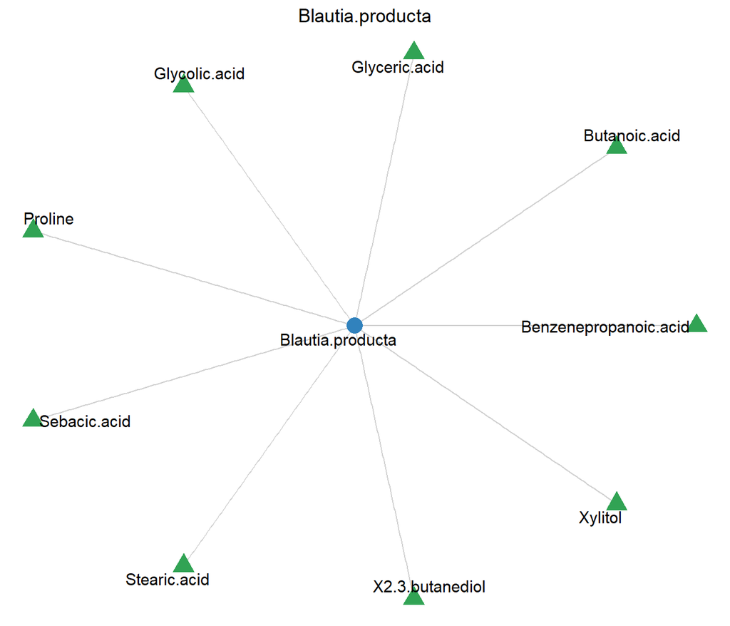

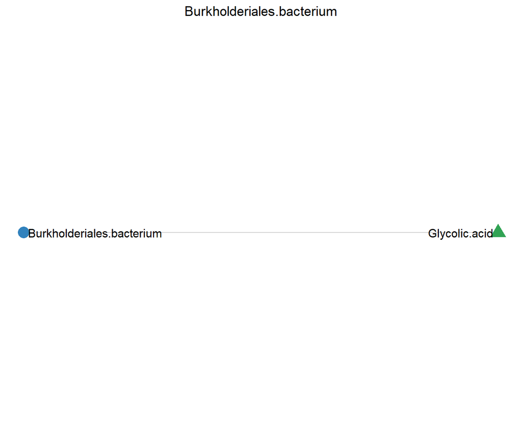

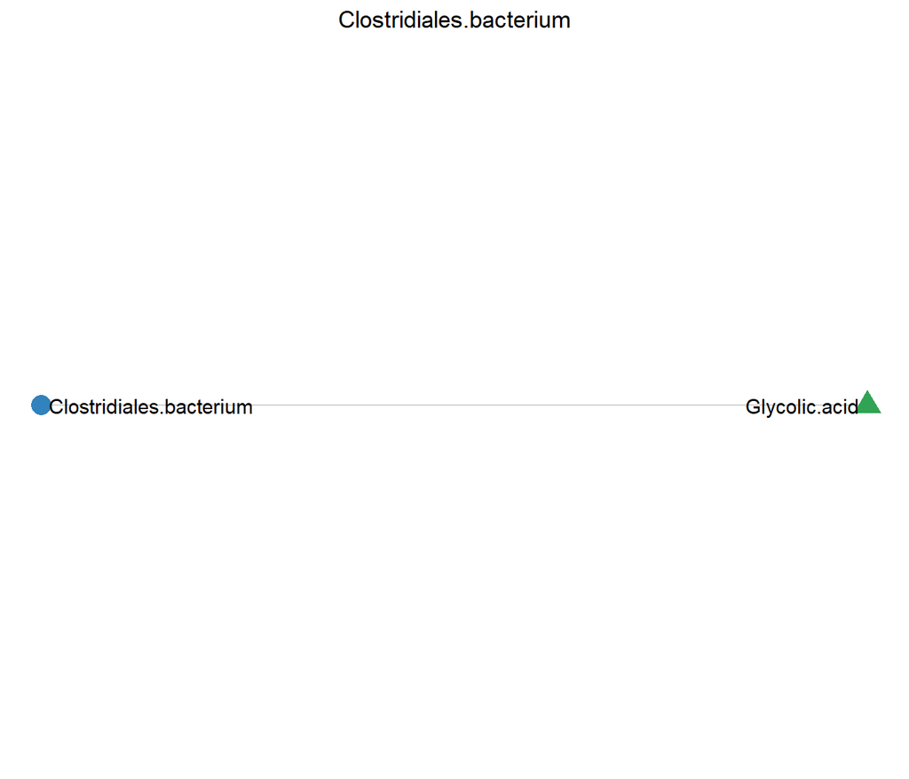

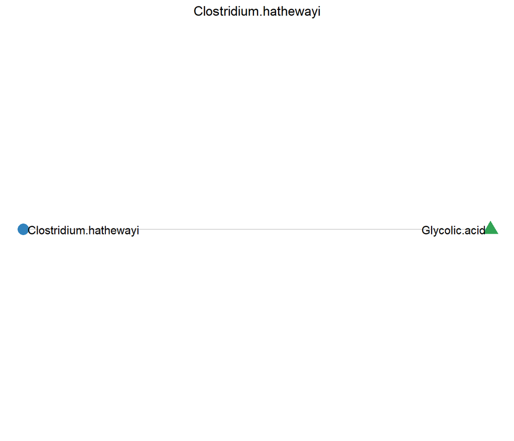

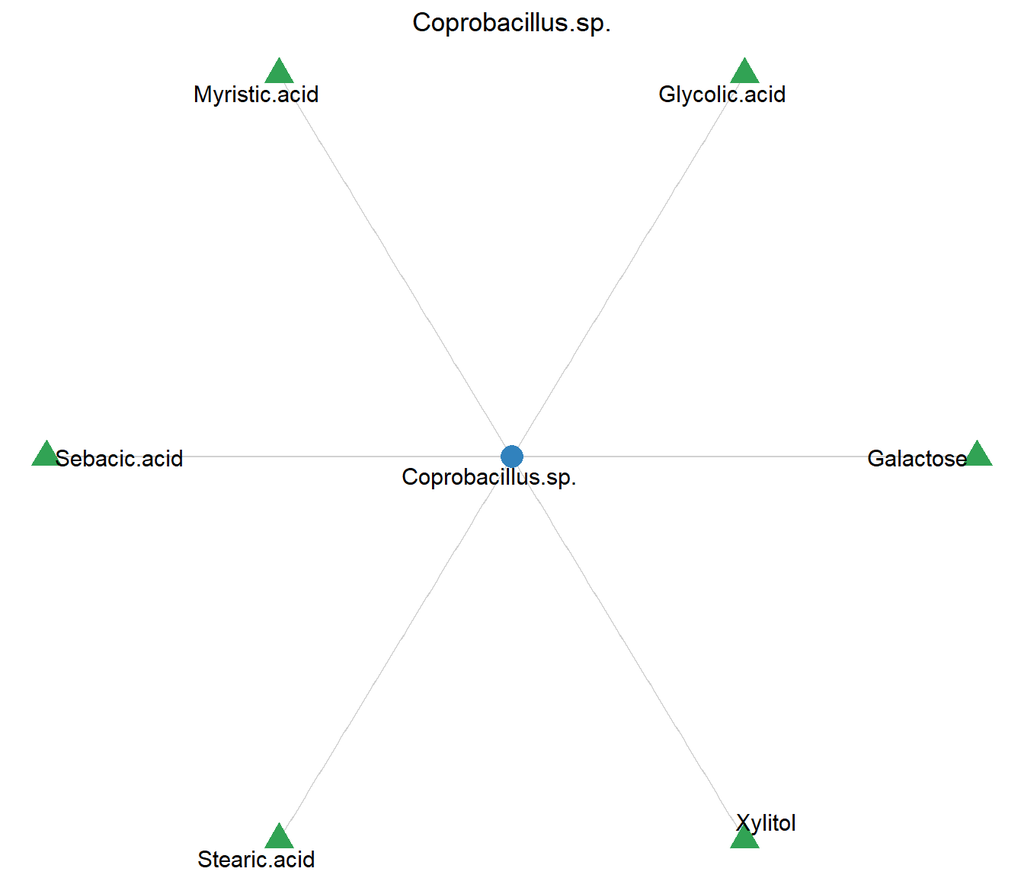

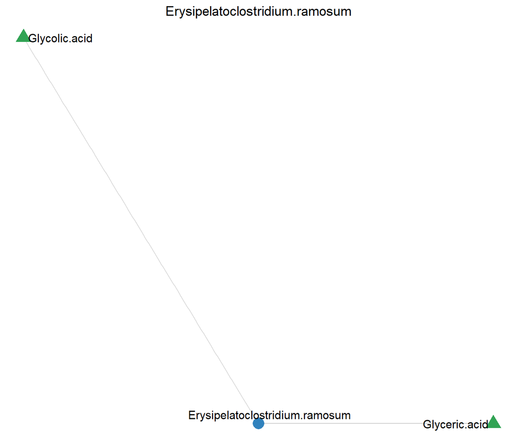

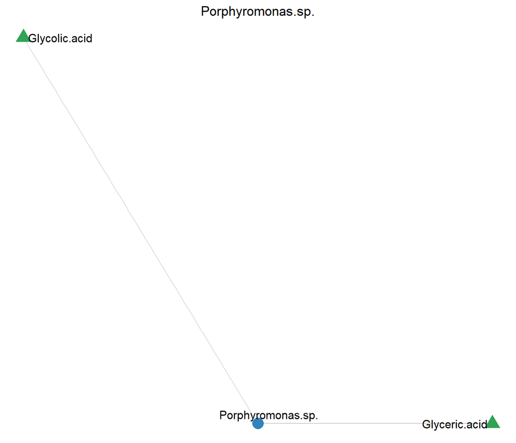

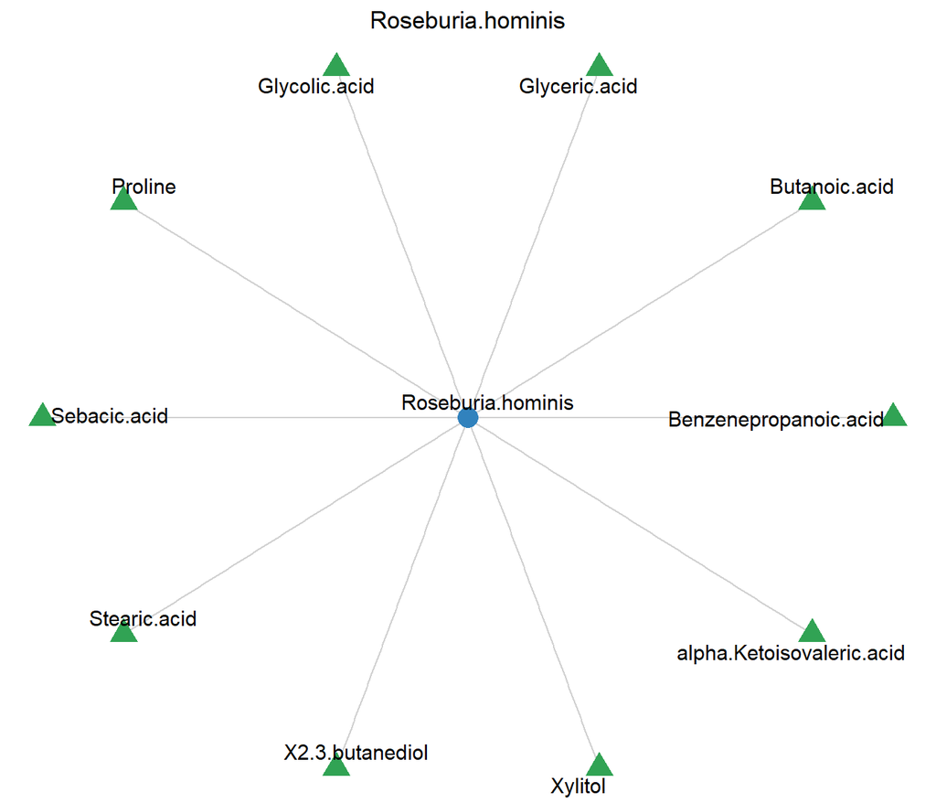

```r
walk(plot_star_by_bacteria(tabla_case), print)
```

## 6.3 Grafo — Control

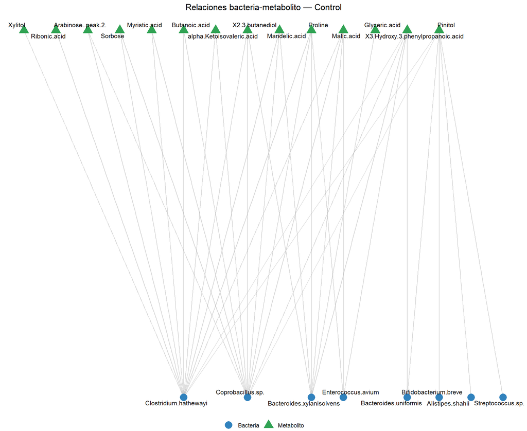

```r
plot_bipartite_graph(tabla_control, "Relaciones bacteria-metabolito — Control")
```

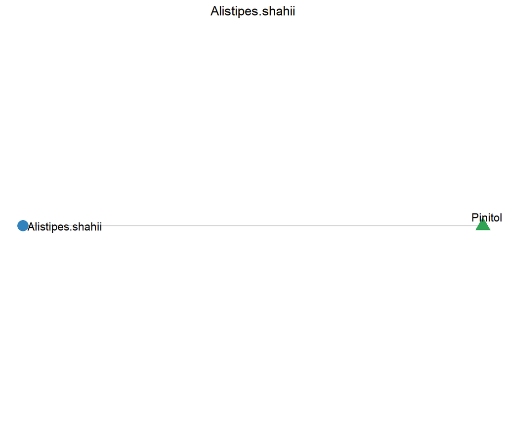

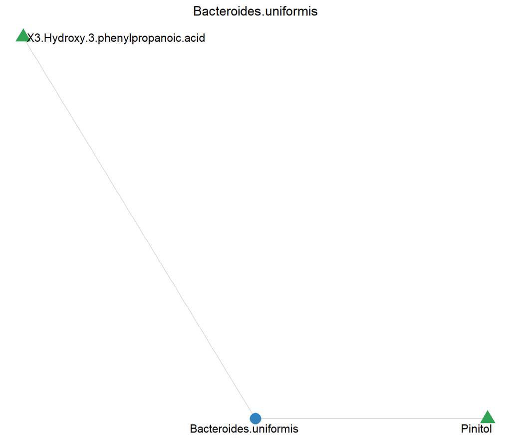

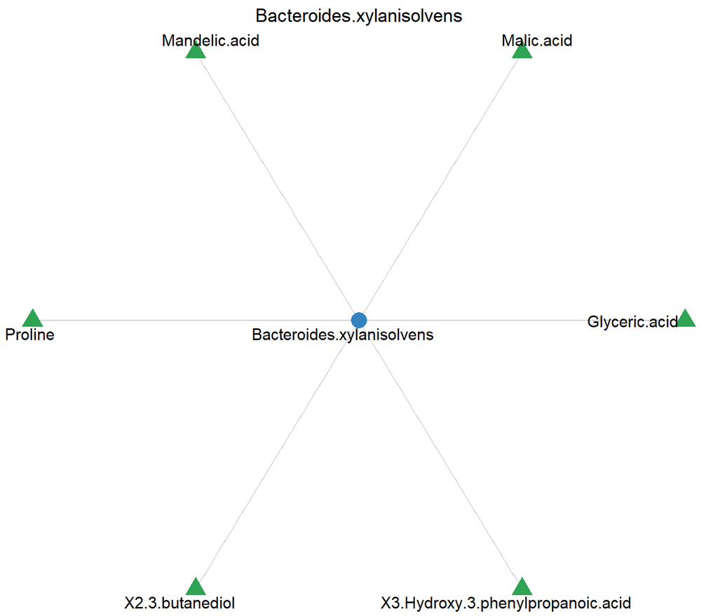

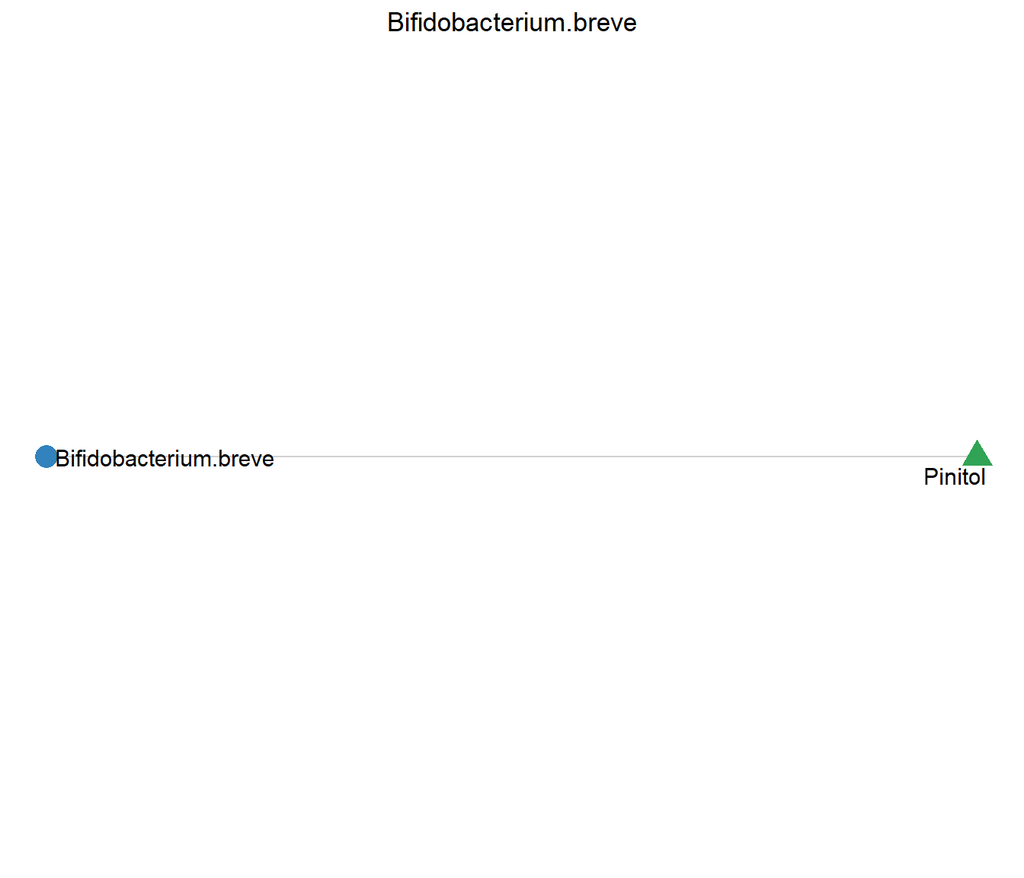

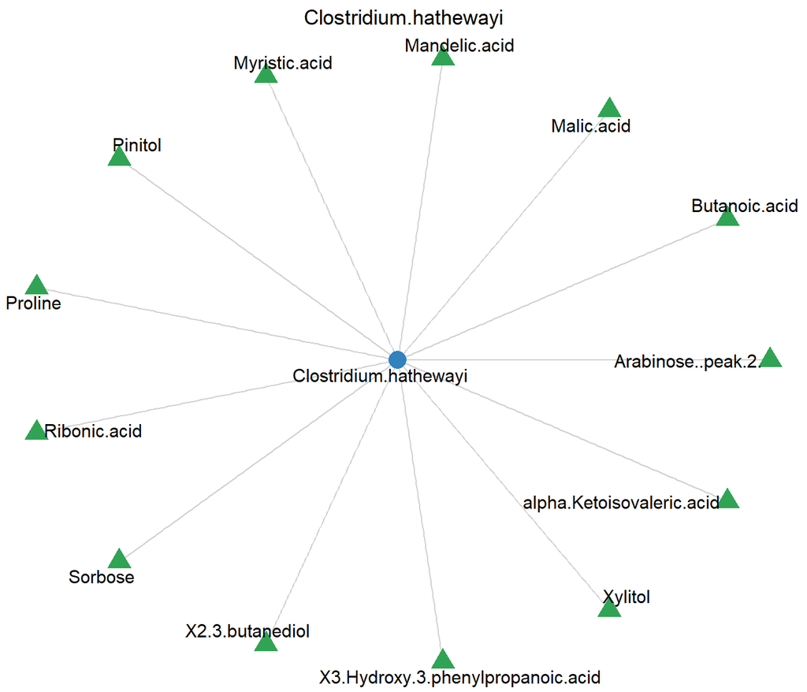

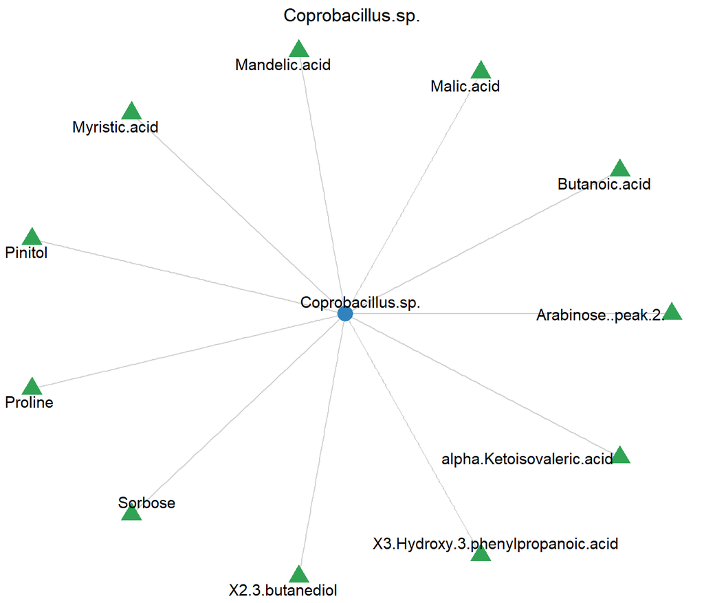

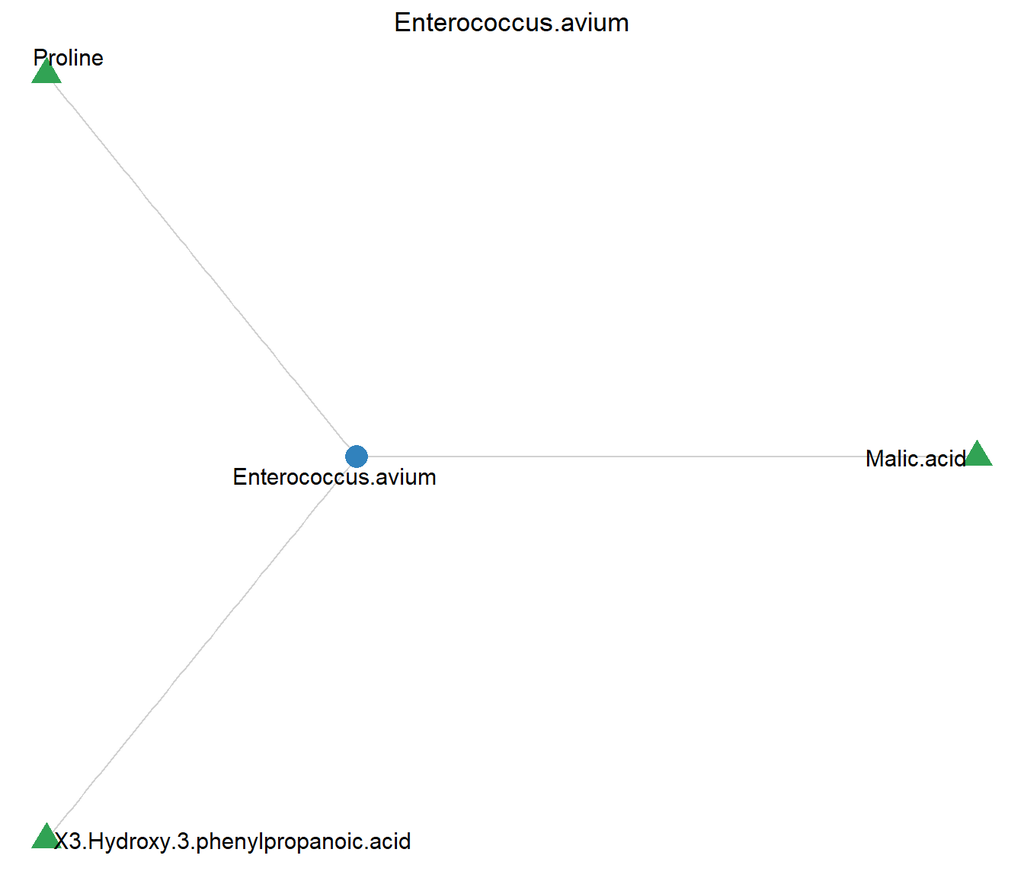

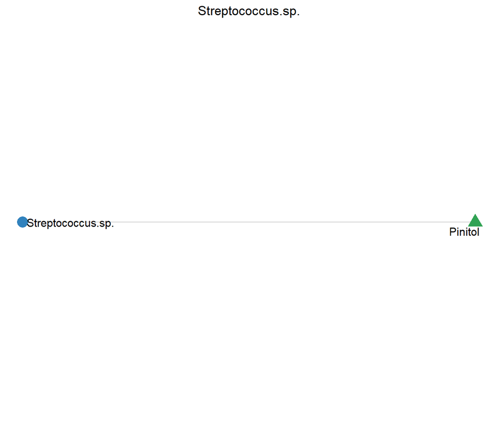

```r
walk(plot_star_by_bacteria(tabla_control), print)
```

# 7. Heatmaps bacteria-metabolito

Alternativa a los grafos que no sufre el problema de solape de etiquetas: una matriz bacteria × metabolito coloreada por el coeficiente de regresión del PLS (extraído de `modelo_pls2$coefficients` / `modelo_case$coefficients` / `modelo_control$coefficients`), con azul para coeficientes negativos, rojo para positivos y blanco en 0.

```r
plot_heatmap_relaciones <- function(tabla, title) {
  ggplot(tabla, aes(x = metabolito, y = bacteria, fill = coeficiente)) +
    geom_tile(color = "grey30", linewidth = 0.6) +
    scale_fill_gradient2(low = "#08519c", mid = "white", high = "#a50f15",
                          midpoint = 0, name = "Coeficiente\nPLS") +
    scale_x_discrete(expand = c(0, 0)) +
    scale_y_discrete(expand = c(0, 0)) +
    labs(title = title, x = NULL, y = NULL,
         caption = "Celdas en gris: sin relación seleccionada mediante permutación") +
    theme_minimal() +
    theme(
      panel.grid = element_blank(),
      panel.background = element_rect(fill = "grey88", color = NA),
      axis.text.x = element_text(angle = 45, hjust = 1, size = 8, face = "bold"),
      axis.text.y = element_text(size = 9, face = "bold"),
      plot.title = element_text(hjust = 0.5),
      plot.caption = element_text(size = 8, hjust = 0, color = "grey40")
    )
}
```

## 7.1 Heatmap — modelo conjunto

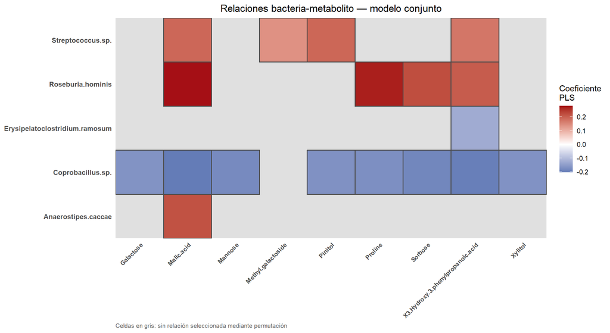

```r
plot_heatmap_relaciones(tabla_relaciones, "Relaciones bacteria-metabolito — modelo conjunto")
```

## 7.2 Heatmap — Case

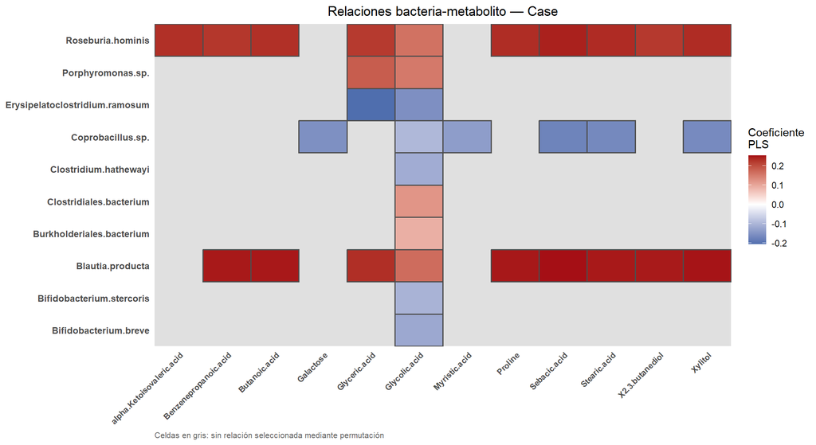

```r
plot_heatmap_relaciones(tabla_case, "Relaciones bacteria-metabolito — Case")
```

## 7.3 Heatmap — Control

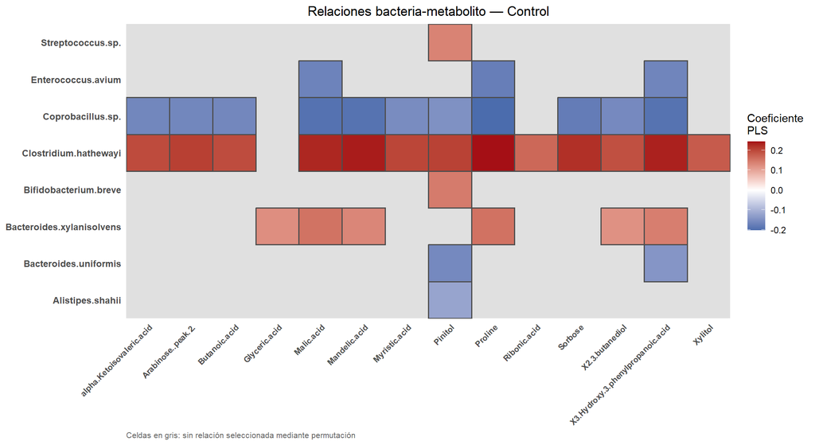

```r
plot_heatmap_relaciones(tabla_control, "Relaciones bacteria-metabolito — Control")
```